# Doorae

coop711

2015년 8월 23일

## 관광두레 주민공동체 현황분석

- 자료 구조 확인

```
## [1] "/Users/coop2711/data"
```

[output not shown]

```
##  [1] "공동체상태와조직형태"      "business_item"
##  [3] "business_open.tbl"         "business_registration.tbl"
##  [5] "business.registration"     "business.registration.ys"
##  [7] "cols.no.summary"           "coord.text"
##  [9] "coord.text.1.2"            "coord.text.2"
## [11] "coord.text.3"              "coord.text.4"
## [13] "corporate_type.tbl"        "corporate.bi"
## [15] "corporate.bp"              "corporate.tbl"
## [17] "doorae"                    "doorae.ys"
## [19] "ecdf.1"                    "items.no.summary"
## [21] "nameorder"                 "noncorporate.bi"
## [23] "noncorporate.bp"           "province"
## [25] "status.vs.business_item"   "status.vs.corporate_type"
## [27] "status.vs.structure"       "stock.co"
```

```
## 'data.frame':    96 obs. of  60 variables:
##  $ 조직명                : chr  "수원누리" "수원화성공예_협" "행궁맛촌" "이웃문화협동조합" ...
##  $ 시도                  : Factor w/ 8 levels "강원","경기",..: 2 2 2 2 2 2 2 2 2 2 ...
##  $ 시군                  : Factor w/ 18 levels "가평","강릉",..: 10 10 10 10 10 12 12 12 12 1 ...
##  $ PD.1                  : Factor w/ 18 levels "경용주","권옥선",..: 3 3 3 3 3 11 11 11 11 16 ...
##  $ PD.2                  : Factor w/ 3 levels "박호철","없음",..: 1 1 1 1 1 2 2 2 2 2 ...
##  $ 공동체상태            : Factor w/ 2 levels "경영개선","창업준비": 2 2 2 1 2 2 1 2 2 2 ...
##  $ 조직형태              : Factor w/ 2 levels "법인","임의단체": 2 2 2 1 2 2 1 1 1 1 ...
##  $ 조직원                : num  4 4 4 5 5 5 40 67 5 5 ...
##  $ 법인유형              : Factor w/ 7 levels "마을회","사단법인",..: 5 5 5 7 5 5 3 7 3 7 ...
##  $ 설립일                : Date, format: "2014-05-01" "2015-03-01" ...
##  $ 사업자등록            : chr  NA "513-80-29465" NA "124-87-43816" ...
##  $ 업태                  : Factor w/ 16 levels "농업","도소매",..: 16 16 16 5 16 16 16 16 16 16 ...
##  $ 종목                  : Factor w/ 30 levels "곡물","공연",..: 30 30 30 11 30 30 30 30 30 30 ...
##  $ 소재지                : Factor w/ 19 levels "가평","강릉",..: 11 11 11 11 11 13 13 13 13 1 ...
```

[output cut: 46 more lines]

- 기초통계 및 요약 파악
- **조직명**:

  | Length | Class | Mode |
  | --- | --- | --- |
  | 96 | character | character |

- **시도**:

  | 강원 | 경기 | 경남 | 경북 | 전남 | 전북 | 충남 | 충북 |
  | --- | --- | --- | --- | --- | --- | --- | --- |
  | 10 | 12 | 11 | 18 | 17 | 18 | 2 | 8 |

- **시군**:

  Table continues below

  | 가평 | 강릉 | 곡성 | 공주 | 김제 | 남원 | 남해 | 무주 |
  | --- | --- | --- | --- | --- | --- | --- | --- |
  | 3 | 5 | 4 | 2 | 5 | 7 | 6 | 6 |

  Table continues below

  | 봉화 | 수원 | 순천 | 양평 | 여수 | 울진 | 인제 | 제천 |
  | --- | --- | --- | --- | --- | --- | --- | --- |
  | 7 | 5 | 6 | 4 | 7 | 7 | 5 | 8 |

  | 청송 | 합천 |
  | --- | --- |
  | 4 | 5 |

- **PD.1**:

  Table continues below

  | 경용주 | 권옥선 | 김용균 | 김형미 | 모세환 | 박영배 |
  | --- | --- | --- | --- | --- | --- |
  | 5 | 5 | 5 | 5 | 6 | 2 |

  Table continues below

  | 박찬용 | 박희축 | 배정근 | 백승완 | 신교진 | 이규봉 |
  | --- | --- | --- | --- | --- | --- |
  | 7 | 6 | 6 | 5 | 4 | 7 |

  | 이재신 | 임태현 | 정태균 | 조성주 | 최병호 | 홍수진 |
  | --- | --- | --- | --- | --- | --- |
  | 8 | 4 | 7 | 3 | 7 | 4 |

- **PD.2**:

  | 박호철 | 없음 | 이광석 |
  | --- | --- | --- |
  | 5 | 85 | 6 |

- **공동체상태**:

  | 경영개선 | 창업준비 |
  | --- | --- |
  | 27 | 69 |

- **조직형태**:

  | 법인 | 임의단체 |
  | --- | --- |
  | 52 | 44 |

- **조직원**:

  | Min. | 1st Qu. | Median | Mean | 3rd Qu. | Max. |
  | --- | --- | --- | --- | --- | --- |
  | 3 | 5 | 7.5 | 14 | 12 | 162 |

- **법인유형**:

  Table continues below

  | 마을회 | 사단법인 | 영농조합법인 | 유한회사 | 임의단체 |
  | --- | --- | --- | --- | --- |
  | 1 | 5 | 22 | 1 | 43 |

  | 주식회사 | 협동조합 |
  | --- | --- |
  | 5 | 19 |

- **인적자원**:

  | 상 | 중 | 하 |
  | --- | --- | --- |
  | 16 | 57 | 23 |

- **물적자원**:

  | 상 | 중 | 하 |
  | --- | --- | --- |
  | 28 | 57 | 11 |

- **재무자원**:

  | 상 | 중 | 하 |
  | --- | --- | --- |
  | 25 | 25 | 46 |

- **정부지원사업**:

  | Min. | 1st Qu. | Median | Mean | 3rd Qu. | Max. |
  | --- | --- | --- | --- | --- | --- |
  | 0 | 0 | 0 | 0.677 | 1 | 8 |

- **지원금.천원.**:

  | Min. | 1st Qu. | Median | Mean | 3rd Qu. | Max. |
  | --- | --- | --- | --- | --- | --- |
  | 0 | 0 | 0 | 425000 | 85000 | 7e+06 |

- **지원사항**:

  | 없음 | HW | SW | SW+HW |
  | --- | --- | --- | --- |
  | 53 | 16 | 7 | 20 |

- **사업아이템**:

  Table continues below

  | 관광기념품 | 교통 | 레저스포츠 | 숙박 | 식음 | 주민여행사 |
  | --- | --- | --- | --- | --- | --- |
  | 14 | 1 | 8 | 11 | 30 | 12 |

  | 체험 |
  | --- |
  | 20 |

- **방문객_2012**:

  | Min. | 1st Qu. | Median | Mean | 3rd Qu. | Max. |
  | --- | --- | --- | --- | --- | --- |
  | 0 | 0 | 0 | 8420 | 0 | 650000 |

- **방문객_2013**:

  | Min. | 1st Qu. | Median | Mean | 3rd Qu. | Max. |
  | --- | --- | --- | --- | --- | --- |
  | 0 | 0 | 0 | 8830 | 0 | 7e+05 |

- **방문객_2014**:

  | Min. | 1st Qu. | Median | Mean | 3rd Qu. | Max. |
  | --- | --- | --- | --- | --- | --- |
  | 0 | 0 | 0 | 10100 | 900 | 8e+05 |

- **매출_2012**:

  | Min. | 1st Qu. | Median | Mean | 3rd Qu. | Max. |
  | --- | --- | --- | --- | --- | --- |
  | 0 | 0 | 0 | 25700 | 0 | 680000 |

- **매출_2013**:

  | Min. | 1st Qu. | Median | Mean | 3rd Qu. | Max. |
  | --- | --- | --- | --- | --- | --- |
  | 0 | 0 | 0 | 23500 | 0 | 910000 |

- **매출_2014**:

  | Min. | 1st Qu. | Median | Mean | 3rd Qu. | Max. |
  | --- | --- | --- | --- | --- | --- |
  | 0 | 0 | 0 | 27800 | 7050 | 7e+05 |

- **성과_법인화**:

  | No | Yes |
  | --- | --- |
  | 44 | 52 |

- **성과_사업착수**:

  | No | Yes |
  | --- | --- |
  | 45 | 51 |

- **성과_사업자등록**:

  | No | Yes |
  | --- | --- |
  | 51 | 45 |

- **성과_상품개발**:

  | No | Yes |
  | --- | --- |
  | 51 | 45 |

- **성과_기술개발**:

  | No | Yes |
  | --- | --- |
  | 77 | 19 |

- **성과_신기술개발**:

  | No | Yes |
  | --- | --- |
  | 91 | 5 |

- **성과_신상품개발**:

  | No | Yes |
  | --- | --- |
  | 93 | 3 |

- **성과_사업장확보**:

  | No | Yes |
  | --- | --- |
  | 43 | 53 |

- **성과_사업장추가**:

  | No | Yes |
  | --- | --- |
  | 92 | 4 |

- **성과_이벤트**:

  | No | Yes |
  | --- | --- |
  | 79 | 17 |

- **성과_SNS**:

  | No | Yes |
  | --- | --- |
  | 94 | 2 |

- **성과_매출_2014**:

  | Min. | 1st Qu. | Median | Mean | 3rd Qu. | Max. |
  | --- | --- | --- | --- | --- | --- |
  | 0 | 0 | 0 | 28400 | 7050 | 7e+05 |

- **성과_매출_2015_3개월**:

  | Min. | 1st Qu. | Median | Mean | 3rd Qu. | Max. |
  | --- | --- | --- | --- | --- | --- |
  | 0 | 0 | 0 | 5590 | 5280 | 103000 |

- **성과_방문객_2014**:

  | Min. | 1st Qu. | Median | Mean | 3rd Qu. | Max. |
  | --- | --- | --- | --- | --- | --- |
  | 0 | 0 | 0 | 10000 | 900 | 8e+05 |

- **성과_방문객_2015_3개월**:

  | Min. | 1st Qu. | Median | Mean | 3rd Qu. | Max. |
  | --- | --- | --- | --- | --- | --- |
  | 0 | 0 | 0 | 706 | 653 | 10200 |

- **성과_정규직_2014**:

  | Min. | 1st Qu. | Median | Mean | 3rd Qu. | Max. |
  | --- | --- | --- | --- | --- | --- |
  | 0 | 0 | 0 | 0.0729 | 0 | 4 |

- **성과_정규직_2015**:

  | Min. | 1st Qu. | Median | Mean | 3rd Qu. | Max. |
  | --- | --- | --- | --- | --- | --- |
  | 0 | 0 | 0 | 1.38 | 0 | 20 |

- **성과_비정규직_2014**:

  | Min. | 1st Qu. | Median | Mean | 3rd Qu. | Max. |
  | --- | --- | --- | --- | --- | --- |
  | 0 | 0 | 0 | 0.198 | 0 | 10 |

- **성과_비정규직_2015**:

  | Min. | 1st Qu. | Median | Mean | 3rd Qu. | Max. |
  | --- | --- | --- | --- | --- | --- |
  | 0 | 0 | 0 | 0.938 | 0 | 24 |

- **사업실적_역량강화**:

  | Min. | 1st Qu. | Median | Mean | 3rd Qu. | Max. |
  | --- | --- | --- | --- | --- | --- |
  | 0 | 0 | 0 | 0.792 | 2 | 3 |

- **사업실적_멘토링**:

  | Min. | 1st Qu. | Median | Mean | 3rd Qu. | Max. |
  | --- | --- | --- | --- | --- | --- |
  | 0 | 0 | 0 | 0.198 | 0 | 3 |

- **사업실적_파일럿**:

  | Min. | 1st Qu. | Median | Mean | 3rd Qu. | Max. |
  | --- | --- | --- | --- | --- | --- |
  | 0 | 0 | 0 | 0.562 | 0 | 6 |

- **사업실적_관광공사**:

  | Min. | 1st Qu. | Median | Mean | 3rd Qu. | Max. |
  | --- | --- | --- | --- | --- | --- |
  | 0 | 0 | 0 | 0.365 | 0 | 3 |

- **기타**:

  | Min. | 1st Qu. | Median | Mean | 3rd Qu. | Max. |
  | --- | --- | --- | --- | --- | --- |
  | 0 | 0 | 0 | 0.917 | 2 | 6 |

- **업력**:

  | Min. | 1st Qu. | Median | Mean | 3rd Qu. | Max. |
  | --- | --- | --- | --- | --- | --- |
  | 0.175 | 1.12 | 1.33 | 2.47 | 3.16 | 12.3 |

- **사업자등록여부**:

  | No | Yes |
  | --- | --- |
  | 49 | 47 |

- “공동체상태” 등을 기초로 2-way 교차분석
1. 공동체상태와 조직형태

1.1 교차표

```
##           조직형태
## 공동체상태 법인 임의단체 계
##   경영개선   24        3 27
##   창업준비   28       41 69
##   계         52       44 96
```

공동체상태와 조직형태

|  | 법인 | 임의단체 |
| --- | --- | --- |
| **경영개선** | 24 | 3 |
| **창업준비** | 28 | 41 |

공동체상태와 조직형태(계)

|  | 법인 | 임의단체 | 계 |
| --- | --- | --- | --- |
| **경영개선** | 24 | 3 | 27 |
| **창업준비** | 28 | 41 | 69 |
| **계** | 52 | 44 | 96 |

공동체상태와 조직형태(%)

|  | 법인 | 임의단체 |
| --- | --- | --- |
| **경영개선** | 89 | 11 |
| **창업준비** | 41 | 59 |

1.2 모자이크 플롯

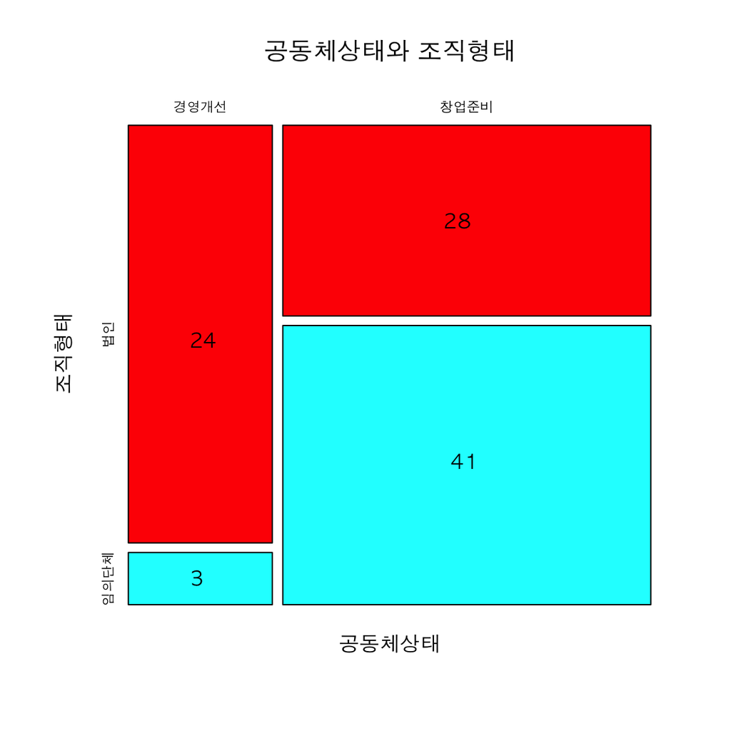

```r
mosaicplot(status.vs.structure, color=rainbow(2), main="공동체상태와 조직형태")
text(coord.text, labels=t(status.vs.structure))
```

생각을 잠시 바꿔보면

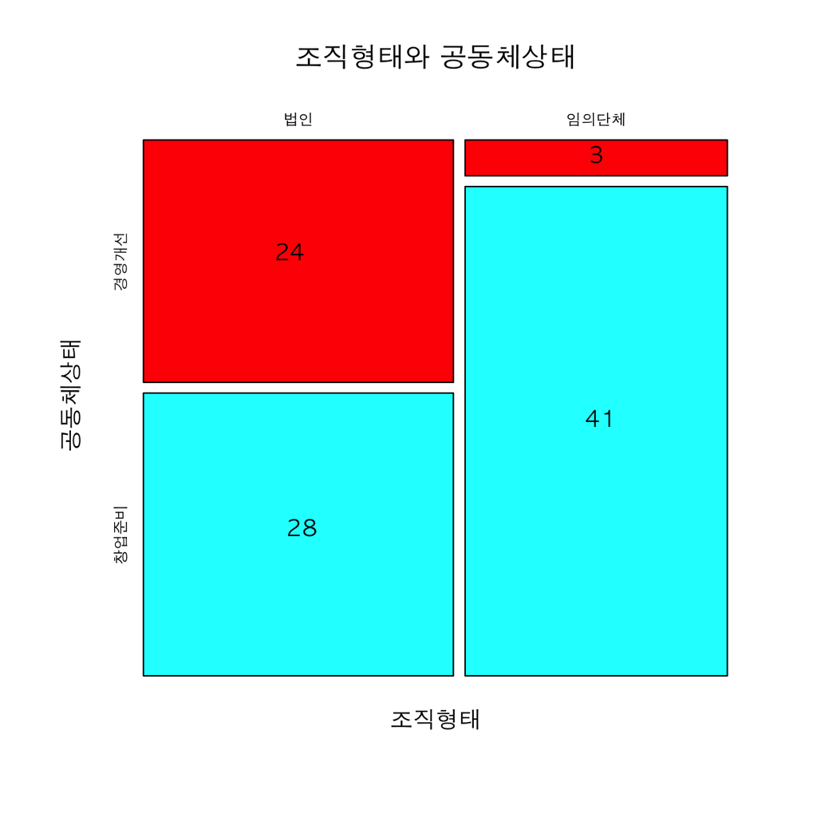

```r
mosaicplot(t(status.vs.structure), color=rainbow(2), main="조직형태와 공동체상태")
text(coord.text.1.2, labels=status.vs.structure)
```

1.3 성장단계 구분에의 시사점

|  | 공동체상태 | 조직명 | 성과_사업착수 | 성과_사업자등록 | 성과_매출_2014 | 성과_매출_2015_3개월 |
| --- | --- | --- | --- | --- | --- | --- |
| 4 | 경영개선 | 이웃문화협동조합 | Yes | Yes | 0 | 7080 |
| 7 | 경영개선 | 수미마을 | Yes | Yes | 222200 | 0 |
| 16 | 경영개선 | 강릉수공예협동조합 | Yes | Yes | 2500 | 0 |
| 17 | 경영개선 | 도배마을 | Yes | Yes | 0 | 0 |
| 18 | 경영개선 | 콩메마루협동조합 | Yes | Yes | 70290 | 9900 |
| 19 | 경영개선 | 소치마을회 | Yes | Yes | 98837 | 23569 |
| 20 | 경영개선 | 하추영농조합 | Yes | Yes | 200000 | 33203 |
| 21 | 경영개선 | 아름다운인제관광 | Yes | Yes | 700000 | 2000 |
| 22 | 경영개선 | 화전민 | Yes | Yes | 150000 | 0 |
| 25 | 경영개선 | 누리마을빵카페 | Yes | Yes | 93300 | 20500 |
| 28 | 경영개선 | 탄지리꽃단지마을 | Yes | Yes | 31000 | 10200 |
| 29 | 경영개선 | 제천수상레저 | Yes | Yes | 54000 | 3000 |
| 35 | 경영개선 | 동편제영농조합법인 | Yes | Yes | 0 | 1300 |
| 37 | 경영개선 | 내일관광여행사협동조합 | Yes | Yes | 0 | 17000 |
| 42 | 경영개선 | 사랑골영농조합법인 | Yes | Yes | 0 | 0 |
| 52 | 경영개선 | 금오도영어영농조합 | Yes | Yes | 16000 | 2400 |
| 58 | 경영개선 | 에코도시락 | Yes | Yes | 15000 | 7500 |
| 61 | 경영개선 | 에코월드공정여행협동조합 | Yes | Yes | 0 | 6130 |
| 62 | 경영개선 | 고돌빼기영농조합법인 | Yes | Yes | 0 | 0 |
| 66 | 경영개선 | 섬진강도깨비마을 | Yes | Yes | 156000 | 67444 |
| 68 | 경영개선 | 주왕산다원 | Yes | Yes | 57000 | 22900 |
| 89 | 경영개선 | 왕지등대마을 | Yes | Yes | 81137 | 3200 |
| 90 | 경영개선 | 꽃내마을 | Yes | Yes | 90000 | 0 |
| 91 | 경영개선 | 독일마을 | Yes | Yes | 18600 | 15600 |

|  | 공동체상태 | 조직명 | 성과_사업착수 | 성과_사업자등록 | 성과_매출_2014 | 성과_매출_2015_3개월 |
| --- | --- | --- | --- | --- | --- | --- |
| 80 | 경영개선 | 왕피천아홉구비 | Yes | Yes | 40000 | 6500 |
| 81 | 경영개선 | 금강송마을 | Yes | Yes | 100000 | 12000 |
| 87 | 경영개선 | 두모마을 | Yes | Yes | 209000 | 3827 |

|  | 공동체상태 | 조직명 | 성과_사업착수 | 성과_사업자등록 | 성과_매출_2014 | 성과_매출_2015_3개월 |
| --- | --- | --- | --- | --- | --- | --- |
| 8 | 창업준비 | 양평펜션협동조합 | No | No | 0 | 0 |
| 9 | 창업준비 | 자연의소리들 | No | No | 0 | 0 |
| 10 | 창업준비 | 가평힐링가든 | Yes | No | 0 | 4130 |
| 11 | 창업준비 | 재즈팜장아찌 | Yes | No | 0 | 6500 |
| 12 | 창업준비 | 에코피아가평발효팜협동조합 | Yes | No | 0 | 8330 |
| 23 | 창업준비 | 공전자연학교 | Yes | Yes | 88100 | 27000 |
| 24 | 창업준비 | 교동민화마을 | Yes | Yes | 5400 | 1700 |
| 26 | 창업준비 | 성내리무암협동조합 | Yes | Yes | 12000 | 11000 |
| 27 | 창업준비 | 수산관광나들이 | No | Yes | 0 | 0 |
| 31 | 창업준비 | 공주드림팜 | Yes | No | 0 | 4041 |
| 33 | 창업준비 | 남원사랑길협동조합 | Yes | Yes | 0 | 2300 |
| 34 | 창업준비 | 남원이색숙소체험협동조합 | Yes | Yes | 0 | 650 |
| 38 | 창업준비 | 남원공예드림협동조합 | Yes | Yes | 0 | 0 |
| 41 | 창업준비 | 벽골제마을주식회사 | No | Yes | 0 | 0 |
| 43 | 창업준비 | 삶의향기공동체 | Yes | Yes | 0 | 0 |
| 48 | 창업준비 | 무주새내기 | Yes | No | 0 | 7600 |
| 51 | 창업준비 | 남도곁꾼협동조합 | Yes | Yes | 0 | 0 |
| 53 | 창업준비 | 신흥영어영농조합 | Yes | Yes | 0 | 0 |
| 55 | 창업준비 | 동고지명품마을 | Yes | Yes | 0 | 2210 |
| 57 | 창업준비 | 버들인영농조합법인 | No | Yes | 0 | 0 |
| 59 | 창업준비 | 두레아트 | Yes | Yes | 0 | 10000 |
| 71 | 창업준비 | 친환경영농조합법인 | No | Yes | 0 | 0 |
| 74 | 창업준비 | 두실마을 | No | No | 0 | 0 |
| 76 | 창업준비 | 오전애권역 | No | No | 0 | 0 |
| 78 | 창업준비 | 다슬기마을 | No | No | 0 | 0 |
| 84 | 창업준비 | 대풍헌사람들 | No | No | 0 | 0 |
| 92 | 창업준비 | 합천공예협동조합 | Yes | No | 0 | 0 |
| 94 | 창업준비 | 고산송희망마을 | No | No | 0 | 0 |

|  | 공동체상태 | 조직명 | 성과_사업착수 | 성과_사업자등록 | 성과_매출_2014 | 성과_매출_2015_3개월 |
| --- | --- | --- | --- | --- | --- | --- |
| 1 | 창업준비 | 수원누리 | No | No | 0 | 0 |
| 2 | 창업준비 | 수원화성공예_협 | No | Yes | 0 | 0 |
| 3 | 창업준비 | 행궁맛촌 | Yes | No | 0 | 20800 |
| 5 | 창업준비 | 마을과사람들 | No | No | 0 | 0 |
| 6 | 창업준비 | 양평카누레저 | Yes | Yes | 25450 | 0 |
| 13 | 창업준비 | 목화열애 | No | No | 0 | 0 |
| 14 | 창업준비 | 강릉도가 | No | No | 0 | 0 |
| 15 | 창업준비 | 영진리부녀회 | No | No | 0 | 0 |
| 30 | 창업준비 | 다림 | No | No | 0 | 4200 |
| 32 | 창업준비 | 공주곰돌빵 | No | No | 0 | 1620 |
| 36 | 창업준비 | 혼불문화예술촌협동조합 | No | No | 0 | 0 |
| 39 | 창업준비 | 남원문화기획사협동조합 | No | No | 0 | 0 |
| 40 | 창업준비 | 징게쟁이들 | No | No | 0 | 0 |
| 44 | 창업준비 | 손누리이야기 | No | No | 0 | 0 |
| 45 | 창업준비 | 무주음식연구회 | No | No | 0 | 0 |
| 46 | 창업준비 | 농촌살이아카데미 | No | No | 0 | 0 |
| 47 | 창업준비 | 덕유산차량이동서비스 | No | No | 0 | 0 |
| 49 | 창업준비 | 숲속나들이 | Yes | No | 0 | 103000 |
| 50 | 창업준비 | 구천동펜션협의회 | No | No | 0 | 0 |
| 54 | 창업준비 | 여자만사람들 | No | No | 0 | 0 |
| 56 | 창업준비 | 수-레인보우 | No | No | 0 | 0 |
| 60 | 창업준비 | 청년창업집단수토리 | Yes | No | 0 | 5000 |
| 63 | 창업준비 | 예그리나 | No | No | 0 | 0 |
| 64 | 창업준비 | 섬진강두꺼비 | No | No | 0 | 0 |
| 65 | 창업준비 | 심청약선마을 | No | No | 0 | 0 |
| 67 | 창업준비 | 미실란낭만부엌 | No | No | 0 | 0 |
| 69 | 창업준비 | 덕다헌 | Yes | No | 12000 | 8328 |
| 70 | 창업준비 | 청송고택운영위원회 | Yes | No | 176620 | 27470 |
| 72 | 창업준비 | 귀농투어사업단 | No | No | 0 | 0 |
| 73 | 창업준비 | 봉화도시락사업단 | No | No | 0 | 0 |
| 75 | 창업준비 | 협곡구비마을 | No | No | 0 | 0 |
| 77 | 창업준비 | 사미정펜션협의회 | No | No | 0 | 0 |
| 79 | 창업준비 | 오산항난전방티 | No | No | 0 | 0 |
| 82 | 창업준비 | 울진로컬푸드관광 | No | No | 0 | 0 |
| 83 | 창업준비 | 망양쪽빛바다 | No | No | 0 | 0 |
| 85 | 창업준비 | 울진기념품사업단 | No | No | 0 | 0 |
| 86 | 창업준비 | 보물섬다이아 | No | No | 0 | 1250 |
| 88 | 창업준비 | 남해펜션1번가 | No | Yes | 0 | 0 |
| 93 | 창업준비 | 동행 | Yes | No | 0 | 4275 |
| 95 | 창업준비 | 오토캠핑장사업자연합 | No | No | 0 | 0 |
| 96 | 창업준비 | 구평마을 | No | No | 0 | 0 |

**공동체상태/조직형태와 사업자등록여부**

|  |  | 사업자등록 여부 | No | Yes |
| --- | --- | --- | --- | --- |
| 경영개선 | 법인 |  | 0 | 24 |
|  | 임의단체 |  | 0 | 3 |
| 창업준비 | 법인 |  | 13 | 15 |
|  | 임의단체 |  | 38 | 3 |

**공동체상태/조직형태와 사업자등록여부(%)**

|  |  | 사업자등록 여부 | No | Yes |
| --- | --- | --- | --- | --- |
| 경영개선 | 법인 |  | 0.0 | 100.0 |
|  | 임의단체 |  | 0.0 | 100.0 |
| 창업준비 | 법인 |  | 46.4 | 53.6 |
|  | 임의단체 |  | 92.7 | 7.3 |

**공동체상태/조직형태와 사업착수여부**

|  |  | 사업착수 여부 | No | Yes |
| --- | --- | --- | --- | --- |
| 경영개선 | 법인 |  | 0 | 24 |
|  | 임의단체 |  | 0 | 3 |
| 창업준비 | 법인 |  | 11 | 17 |
|  | 임의단체 |  | 34 | 7 |

**공동체상태/조직형태와 사업착수여부(%)**

|  |  | 사업착수 여부 | No | Yes |
| --- | --- | --- | --- | --- |
| 경영개선 | 법인 |  | 0 | 100 |
|  | 임의단체 |  | 0 | 100 |
| 창업준비 | 법인 |  | 39 | 61 |
|  | 임의단체 |  | 83 | 17 |

2. 공동체상태와 법인유형

2.1 교차표

ㅇ공동체상태와 조직유형

|  | 마을회 | 사단법인 | 영농조합법인 | 유한회사 | 임의단체 | 주식회사 | 협동조합 |
| --- | --- | --- | --- | --- | --- | --- | --- |
| 경영개선 | 1 | 2 | 13 | 1 | 2 | 3 | 5 |
| 창업준비 | 0 | 3 | 9 | 0 | 41 | 2 | 14 |

ㅇ주식회사인 공동체사업체

|  | 공동체상태 | 조직명 |
| --- | --- | --- |
| 21 | 경영개선 | 아름다운인제관광 |
| 29 | 경영개선 | 제천수상레저 |
| 41 | 창업준비 | 벽골제마을주식회사 |
| 55 | 창업준비 | 동고지명품마을 |
| 58 | 경영개선 | 에코도시락 |

2.2 모자이크 플롯

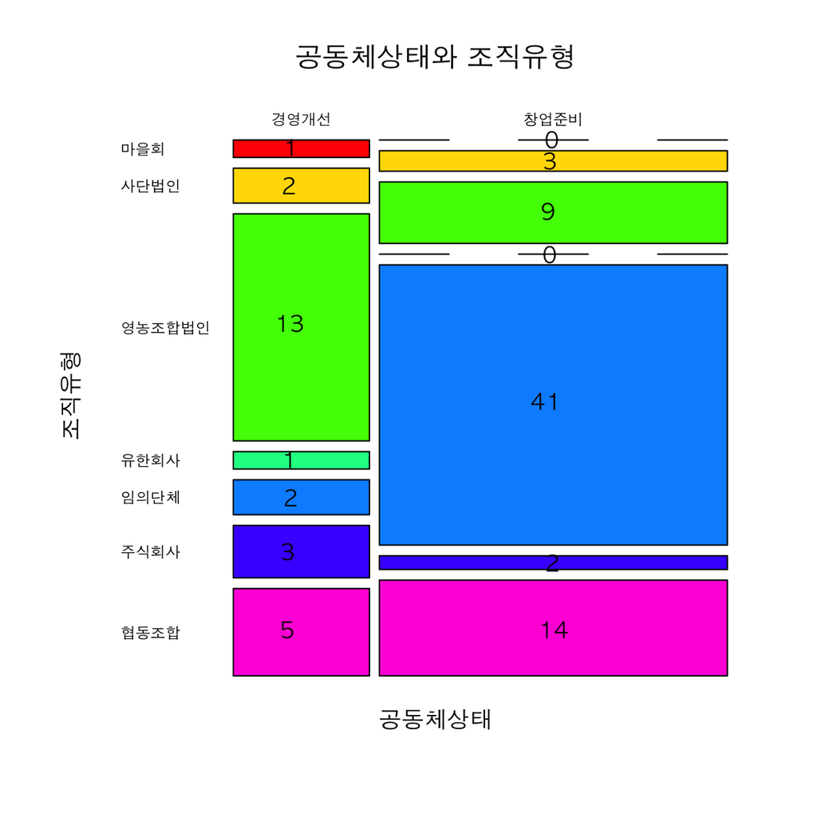

```r
mosaicplot(status.vs.corporate_type, color=rainbow(7), main="공동체상태와 조직유형", las=1)
text(coord.text.2, labels=t(status.vs.corporate_type))
```

3. 공동체상태와 사업아이템

3.1 교차표

|  | 관광기념품 | 교통 | 레저스포츠 | 숙박 | 식음 | 주민여행사 | 체험 |
| --- | --- | --- | --- | --- | --- | --- | --- |
| 경영개선 | 1 | 0 | 4 | 1 | 10 | 2 | 9 |
| 창업준비 | 13 | 1 | 4 | 10 | 20 | 10 | 11 |

3.2 모자이크 플롯

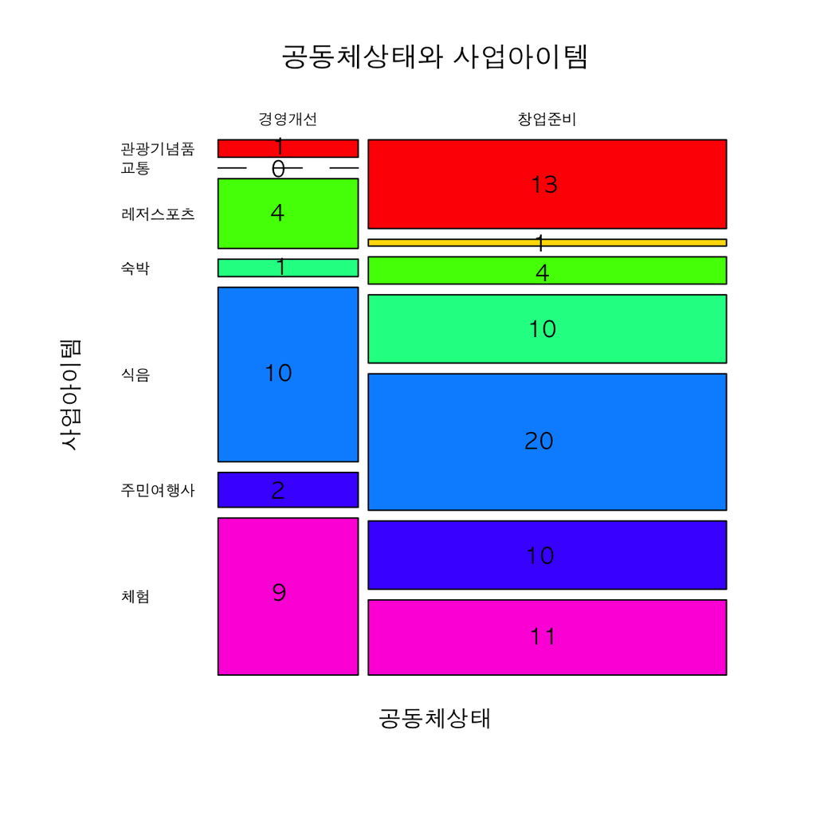

```r
mosaicplot(status.vs.business_item, color=rainbow(7), main="공동체상태와 사업아이템", las=1)
text(coord.text.3, labels=t(status.vs.business_item))
```

4. 공동체상태와 업력

4.1 요약표

```r
pander(tapply(doorae$"업력", doorae$"공동체상태", summary))
```

- **경영개선**:

  | Min. | 1st Qu. | Median | Mean | 3rd Qu. | Max. |
  | --- | --- | --- | --- | --- | --- |
  | 1.22 | 2.47 | 4.39 | 4.83 | 6.05 | 12.3 |

- **창업준비**:

  | Min. | 1st Qu. | Median | Mean | 3rd Qu. | Max. |
  | --- | --- | --- | --- | --- | --- |
  | 0.175 | 0.885 | 1.3 | 1.55 | 1.47 | 11.6 |

4.2 Box Plot

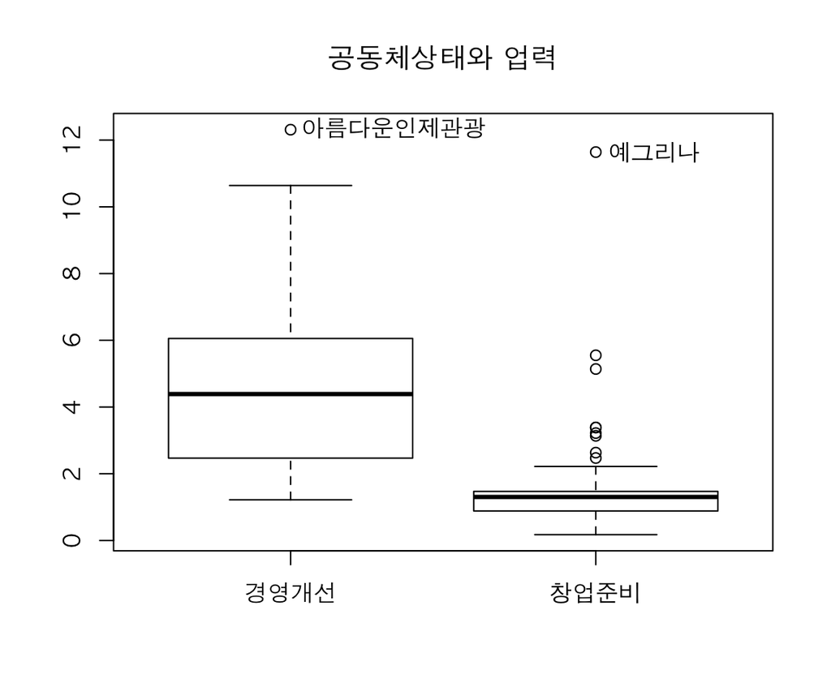

4.3 ECDF

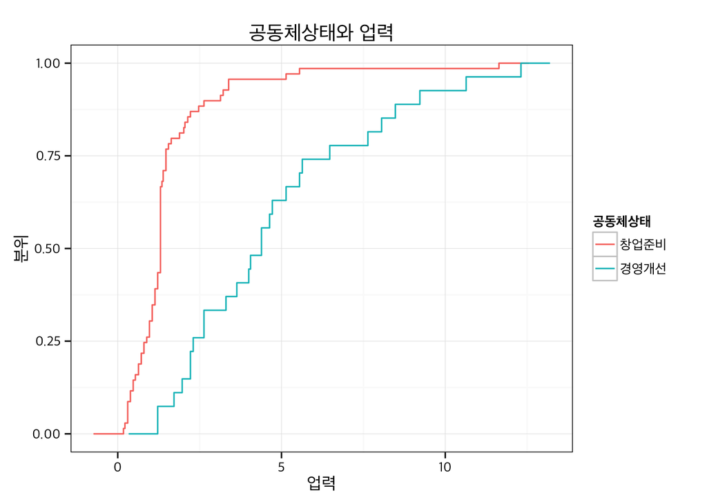

4.4 Dot Chart

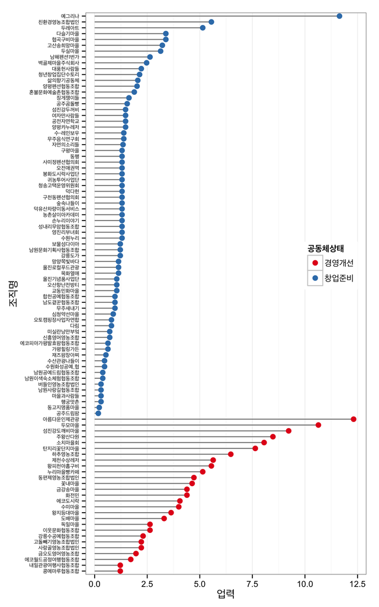

5. 방문객과 매출

5.1 공동체 상태 별 평균과 중위값 비교

| 공동체상태 | 성과_방문객_2014 | 성과_방문객_2015_3개월 | 성과_매출_2014 | 성과_매출_2015_3개월 |
| --- | --- | --- | --- | --- |
| 경영개선 | 35030 | 1756 | 89069 | 10195 |
| 창업준비 | 249 | 295 | 4631 | 3788 |

| 공동체상태 | 성과_방문객_2014 | 성과_방문객_2015_3개월 | 성과_매출_2014 | 성과_매출_2015_3개월 |
| --- | --- | --- | --- | --- |
| 경영개선 | 3477 | 870 | 54000 | 6130 |
| 창업준비 | 0 | 0 | 0 | 0 |

5.2 2014, 2015년도 방문객 및 매출 순 조직명 파악

|  | 공동체상태 | 조직명 | 성과_방문객_2014 |
| --- | --- | --- | --- |
| 91 | 경영개선 | 독일마을 | 800000 |
| 58 | 경영개선 | 에코도시락 | 28000 |
| 81 | 경영개선 | 금강송마을 | 17000 |
| 21 | 경영개선 | 아름다운인제관광 | 15000 |
| 87 | 경영개선 | 두모마을 | 13896 |
| 7 | 경영개선 | 수미마을 | 10560 |
| 25 | 경영개선 | 누리마을빵카페 | 8220 |
| 20 | 경영개선 | 하추영농조합 | 7234 |
| 89 | 경영개선 | 왕지등대마을 | 6511 |
| 16 | 경영개선 | 강릉수공예협동조합 | 6050 |
| 90 | 경영개선 | 꽃내마을 | 5800 |
| 23 | 창업준비 | 공전자연학교 | 5460 |
| 70 | 창업준비 | 청송고택운영위원회 | 5384 |
| 22 | 경영개선 | 화전민 | 5000 |
| 68 | 경영개선 | 주왕산다원 | 3800 |
| 18 | 경영개선 | 콩메마루협동조합 | 3477 |
| 29 | 경영개선 | 제천수상레저 | 3400 |
| 19 | 경영개선 | 소치마을회 | 3358 |
| 28 | 경영개선 | 탄지리꽃단지마을 | 3154 |
| 80 | 경영개선 | 왕피천아홉구비 | 3000 |

|  | 공동체상태 | 조직명 | 성과_방문객_2015_3개월 |
| --- | --- | --- | --- |
| 87 | 경영개선 | 두모마을 | 10154 |
| 89 | 경영개선 | 왕지등대마을 | 8300 |
| 66 | 경영개선 | 섬진강도깨비마을 | 7609 |
| 37 | 경영개선 | 내일관광여행사협동조합 | 6600 |
| 3 | 창업준비 | 행궁맛촌 | 5200 |
| 33 | 창업준비 | 남원사랑길협동조합 | 2950 |
| 49 | 창업준비 | 숲속나들이 | 2210 |
| 25 | 경영개선 | 누리마을빵카페 | 2100 |
| 61 | 경영개선 | 에코월드공정여행협동조합 | 2095 |
| 20 | 경영개선 | 하추영농조합 | 1823 |
| 26 | 창업준비 | 성내리무암협동조합 | 1300 |
| 23 | 창업준비 | 공전자연학교 | 1200 |
| 80 | 경영개선 | 왕피천아홉구비 | 1200 |
| 68 | 경영개선 | 주왕산다원 | 1170 |
| 48 | 창업준비 | 무주새내기 | 1120 |
| 34 | 창업준비 | 남원이색숙소체험협동조합 | 1100 |
| 35 | 경영개선 | 동편제영농조합법인 | 1100 |
| 24 | 창업준비 | 교동민화마을 | 1080 |
| 21 | 경영개선 | 아름다운인제관광 | 1000 |
| 81 | 경영개선 | 금강송마을 | 1000 |

|  | 공동체상태 | 조직명 | 성과_매출_2014 |
| --- | --- | --- | --- |
| 21 | 경영개선 | 아름다운인제관광 | 700000 |
| 7 | 경영개선 | 수미마을 | 222200 |
| 87 | 경영개선 | 두모마을 | 209000 |
| 20 | 경영개선 | 하추영농조합 | 200000 |
| 70 | 창업준비 | 청송고택운영위원회 | 176620 |
| 66 | 경영개선 | 섬진강도깨비마을 | 156000 |
| 22 | 경영개선 | 화전민 | 150000 |
| 81 | 경영개선 | 금강송마을 | 100000 |
| 19 | 경영개선 | 소치마을회 | 98837 |
| 25 | 경영개선 | 누리마을빵카페 | 93300 |
| 90 | 경영개선 | 꽃내마을 | 90000 |
| 23 | 창업준비 | 공전자연학교 | 88100 |
| 89 | 경영개선 | 왕지등대마을 | 81137 |
| 18 | 경영개선 | 콩메마루협동조합 | 70290 |
| 68 | 경영개선 | 주왕산다원 | 57000 |
| 29 | 경영개선 | 제천수상레저 | 54000 |
| 80 | 경영개선 | 왕피천아홉구비 | 40000 |
| 28 | 경영개선 | 탄지리꽃단지마을 | 31000 |
| 6 | 창업준비 | 양평카누레저 | 25450 |
| 91 | 경영개선 | 독일마을 | 18600 |

|  | 공동체상태 | 조직명 | 성과_매출_2015_3개월 |
| --- | --- | --- | --- |
| 49 | 창업준비 | 숲속나들이 | 103000 |
| 66 | 경영개선 | 섬진강도깨비마을 | 67444 |
| 20 | 경영개선 | 하추영농조합 | 33203 |
| 70 | 창업준비 | 청송고택운영위원회 | 27470 |
| 23 | 창업준비 | 공전자연학교 | 27000 |
| 19 | 경영개선 | 소치마을회 | 23569 |
| 68 | 경영개선 | 주왕산다원 | 22900 |
| 3 | 창업준비 | 행궁맛촌 | 20800 |
| 25 | 경영개선 | 누리마을빵카페 | 20500 |
| 37 | 경영개선 | 내일관광여행사협동조합 | 17000 |
| 91 | 경영개선 | 독일마을 | 15600 |
| 81 | 경영개선 | 금강송마을 | 12000 |
| 26 | 창업준비 | 성내리무암협동조합 | 11000 |
| 28 | 경영개선 | 탄지리꽃단지마을 | 10200 |
| 59 | 창업준비 | 두레아트 | 10000 |
| 18 | 경영개선 | 콩메마루협동조합 | 9900 |
| 12 | 창업준비 | 에코피아가평발효팜협동조합 | 8330 |
| 69 | 창업준비 | 덕다헌 | 8328 |
| 48 | 창업준비 | 무주새내기 | 7600 |
| 58 | 경영개선 | 에코도시락 | 7500 |